# The Commuter’s Emotional Cost: How Transportation Shapes Mental Health

Katherine Zhang

How Americans get to work may have more to do with how they feel than many realize. The visualizations of the analysis done on 3,142 U.S. counties, scatterplots in the figures below illustrate these associations. Group A contains all U.S. counties, while Group B contains 466 urban counties with population densities of over 250 people per square mile.

Each point represents a single county, with the x-axis capturing the percentage of commuters using a specific transportation mode and the y-axis reflecting the local adult depression rate. A regression line is drawn to show the national trendline. Sloping downward means less depression with a higher percentage of a specific transportation mode, and vice versa.

## Driving Ourselves Down

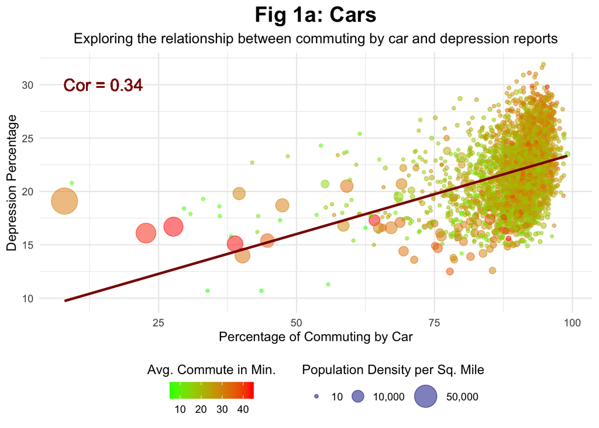

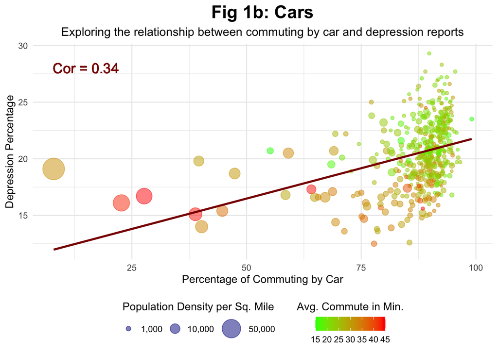

Cars remain the backbone of American commuting, but the data suggests they may be exacting a psychological toll. Nationally, a positive correlation (r = 0.34) links higher driving rates to higher depression. The pattern persists in urban counties as well, where congestion and commute lengths are often worse.

The reasons are likely familiar: long, solitary drives, chronic traffic stress, and the sedentary nature of car travel. In metropolitan areas like Los Angeles, where commutes routinely stretch past 30 minutes, the convenience of a car may be overshadowed by the strain it introduces.

## The Transit Advantage

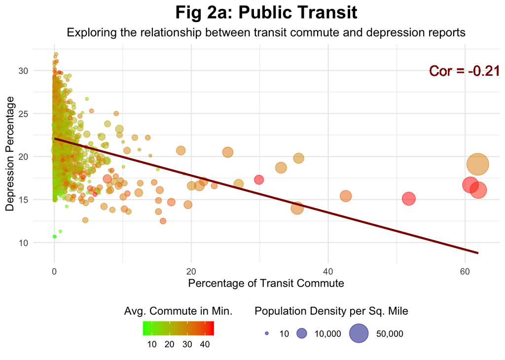

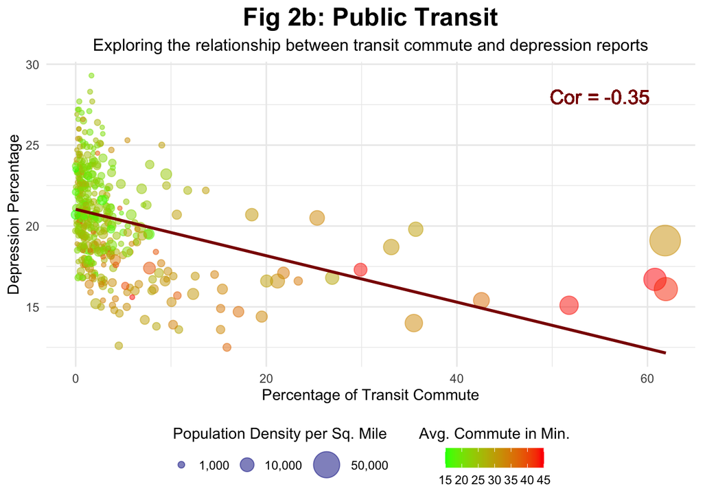

The trend flips with public transportation. Nationwide, the link between transit use and depression is modest (r = -0.21), but it strengthens in urban areas (r = -0.35), where buses, subways, and trains are more accessible.

For example, take New York City, where more than 60 percent of residents use public transit. Many studies have credited urbanization to stress and higher mental health risks. But despite New York’s size and intensity, it shows lower adult depression rates than many smaller, car-dependent countries with shorter commutes.

Transit commuting may provide mental health benefits: lower stress, more physical activity, and occasional social interaction, whether it’s a nod to the bus driver or a brief chat at the subway platform.

## Mixed Signals from Walking and Biking

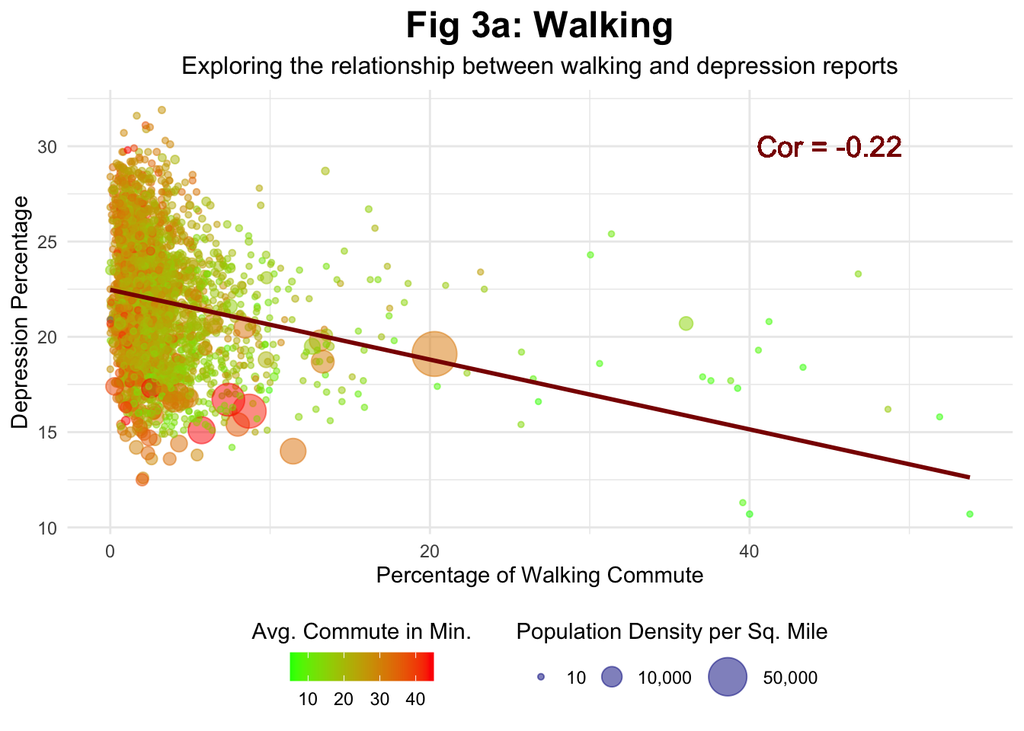

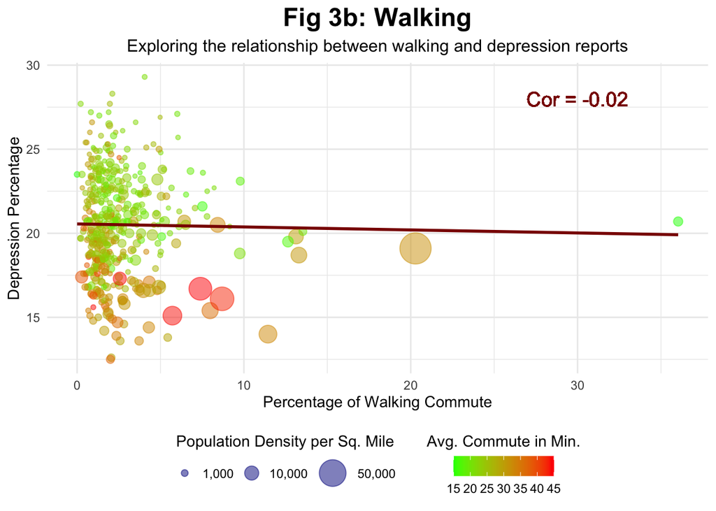

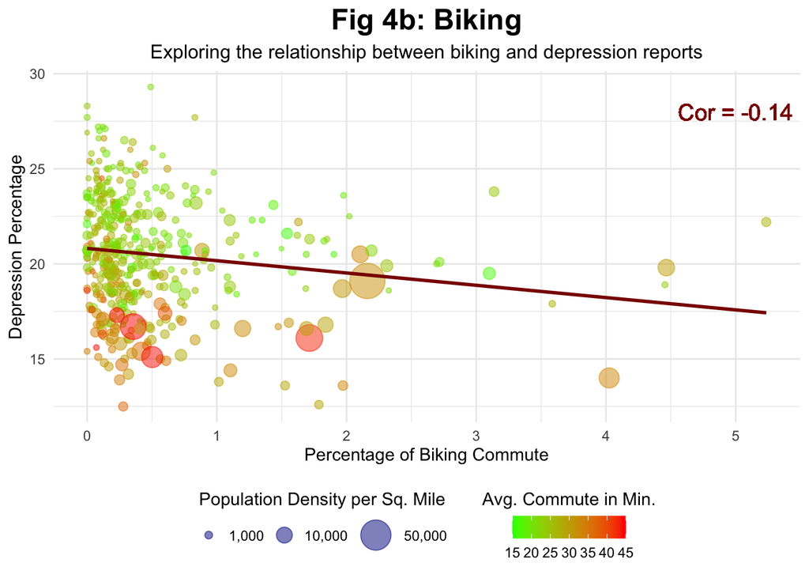

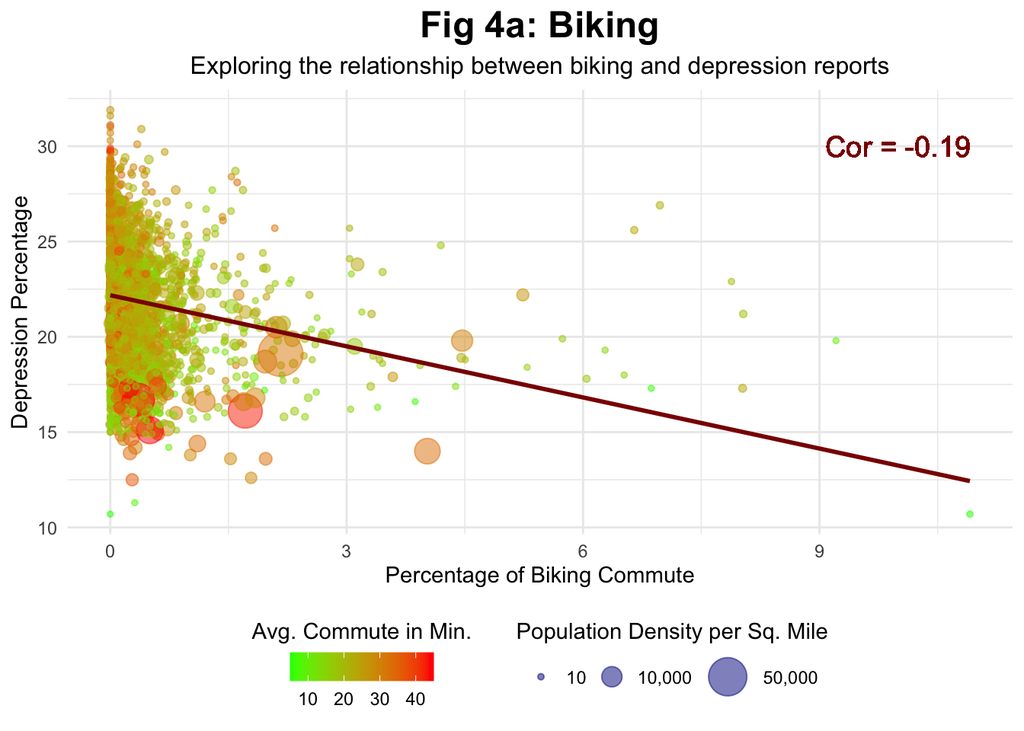

Walking and biking, too, are associated with better mental health. Nationally, walking correlates with lower depression (r = -0.22), as does biking (r = -0.19). But in urban counties, these relationships weaken, walking drops to a near-zero correlation (r = -0.02), and biking to -0.14.

Why the shift? In rural and suburban areas, walking or biking may reflect a healthy, deliberate lifestyle. In dense cities, however, it may signal economic necessity or limited transit access. A peaceful stroll through Vermont farmland is a far cry from dodging traffic on a Bronx intersection.

## A Public Health Opportunity

Correlation does not prove causation. But the consistency across thousands of counties signals something worth examining. Transportation infrastructure is not just about mobility, it may be a lever for emotional well-being. Policymakers and planners aiming to support public health might consider how people move through their cities. Investments in public transit, bike lanes, and walkable streets could serve dual purposes: reducing traffic and improving mental health.

For many, commuting is an unavoidable part of the day. But with thoughtful design and policy, it could become a pathway to feeling better.